# PrinStat - Lab 2: Descriptive statistics

# Your turn!

In the second lab, it is up to you to do descriptive analyses of another, more extended, dataset. You can work in groups.

```r
dat <- read.table("phd_ghent_1000.dat", header = TRUE)
```

## Background and problem setting

Over the past decades, Europe has experienced an increasing demand for graduates and PhD’s to support the development of the knowledge based economy’s key technologies. In response, one has witnessed an increasing inflow of doctoral students in general as well as specifically in Flanders and Ghent. For governments and policy makers who support the doctoral students, this raises the question whether the current system works well: who is flowing in and is the training (cost-)effective?

Against this background, SOOI, an Interuniversity consortium grant was awarded by the Flemish government. In the context of SOOI, Ghent university focused on studying the trajectory of PhD’s, doctoral careers and the mobility of researchers.

In this lab, we provide you with a specific subset of the Ghent University data and ask you to do some data cleaning, if necessary, and then do an analysis.

## Data base

Here we wish to study the population that started between September 1, 1991 and September 1, 2003 in an appointment where the doctoral training gets initiated. For this purpose, we first selected those records that correspond to a first appointment in a doctoral training track (excluding, for instance, administrative staff and practical training assistants). This left 5266 individual observations. Out of those, we have drawn a random sample of 1000 observations. The data set is called `phd_ghent_1000.dat` and consists of the following variables (i.e. a selection of the original variables):

- `age`: age at beginning of appointment
- `gender`: gender (`M` = man, `W` = woman)
- `belgian`: `O` = other nationality, `B` = Belgian nationality
- `degree`: master degree obtained (`5` = unknown, `6` = satisfactorily, `7` = cum laude, `8` = magna cum laude, `9` = summa cum laude, `10` = summa cum laude + felicitations)
- `startdate`: date of start of appointment, in days since December 31, 1899
- `months`: months of appointment until completion of the PhD
- `phd`: `N` = PhD not obtained, `Y` = PhD obtained
- `years`: rounded number of years between start of appointment and completion of the PhD
- `totdfte`: number of full time equivalent (FTE) years of appointment until completion of the PhD
- `meandfte`: mean FTE over the appointment period
- `level`: level of appointment (`aspirant FWO (WP-BD)`, `assistent`, `bijz. doctoraatsbeurs FWO (WP-BD)`, `doctoraatsbursaal`, `ICM-bursaal`, `IMEC predoctoraal onderzoeker`, `IWONL-bursaal`, `IWT-bursaal`, `Klinische doctoraatsbeurs FWO`, `VIB-junior onderzoeker`, `wetenschappelijk medewerker`, `wetenschappelijke projectmedewerker MML`)
- `class` (*you can ignore this variable in your analysis!*): classification category of appointment (`11` = unknown, `1a` = paid AAP, `1c` = temporary AAP, `2` = FWO-scholarship, `3` = IWT-scholarship, `4a` = personal scholarship, `5a` = FWO-, BOF- and IUAP-projects (scholarship), `5b` = FWO-, BOF- and IUAP-projects (WM), `6a` = other projects (scholarship), `6b` = other projects (WM), `7a` = other juniors (scholarship), `7b` = other juniors (WM))
- `faculty`: faculty appointed (`CA` = central administration, `DI` = Veterinary sciences, `EB` = Economics, `FW` = Pharmaceutical sciences, `GE` = Medicine, kinesiology and rehabilitation sciences, `LA` = Agricultural and applied biological science, `LW` = Arts and philosophy, `PP` = Psychology and educational sciences, `PS` = Social and political sciences, `RE` = Law, `TW` = Applied Sciences, `WE` = Sciences)

## Descriptive analysis

1. Consider steps to be taken for data cleaning and screening purposes.
2. Summarize any inconsistencies and decide how you will handle this. Produce a clean dataset to work with.
3. Specify a key question in terms of the data relating to PhD success (i.e. the proportion of students who obtained a PhD).
4. *(Optional:)* Try to come up with a protocol (of one page) discussing how your data cleaning helps you to answer your key research question.

## Missing data, censoring and outliers

Other topics, such as *incomplete data* and *outliers*, might also need to be taken into consideration in order to draw valid conclusions. Both missing data and outliers can, in some cases, seriously distort the results. However, unless data values are naturally implausible (e.g. a body length of 20 m) or seem to point to coding errors (e.g. a negative body weight), plainly removing outliers from the data usually is not considered a very good practice. One should always try to reflect upon the underlying cause for an observation being an outlier or being missing. If possible (and practically feasible), try to trace the data back to its source (e.g. consult the person that has collected the data) to gain more information that might help you judge about the validity of outlying observations. If the data is heavily skewed but there is no reason to doubt the validity of extreme cases, then summary measures such as the *mean* might in fact be unbiased but will generally not be the most informative to learn about central tendency. In those cases one could opt for using more robust measures such as the *median*, which will give a better reflection of the central tendency.

As long as *missing values* can be assumed to appear at random (i.e. are not associated with the value that would have been observed if it were not missing), results will generally not be biased. In most cases, however, this is a relatively strong assumption to make. This topic is considered in more detail in the elective course *Causal Machine Learning*.

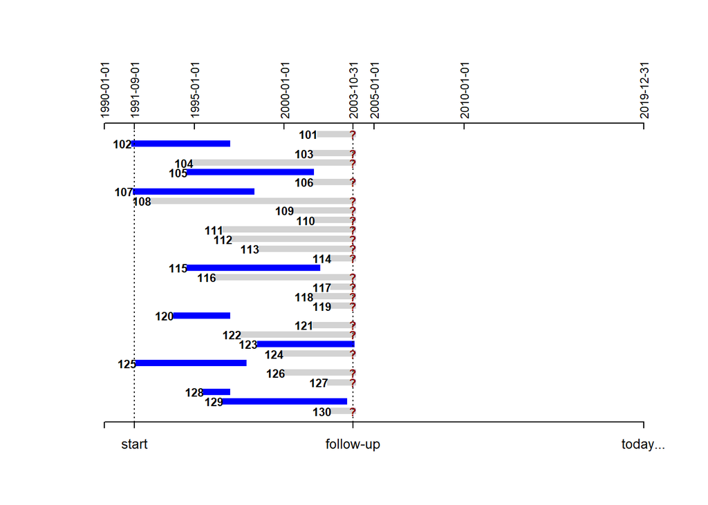

A related topic, which might be particularly relevant in this setting, is *censoring*: since many PhD students might not (yet) have obtained a PhD by the time the study is finished, the duration of their PhD is simply not known (yet) and hence missing. For some students, however, this particular type of missingness, known as *right censoring*, might instead be caused by loss to follow-up (i.e. dropout from the study). One might also wonder whether, how and which results are influenced by PhD students who quit without finishing their PhD (i.e. if the event of interest actually never occurs). These topics are considered in more detail in the elective course *Survival Analysis*.

# Useful R code

The following commands do not solve this Lab for you, but they may help to put you on the right track:

```r
head(dat)    # first six observations
```

```r
tail(dat)    # last six observations
```

```r
names(dat)    # names of the variables of the dataset
```

```r
dim(dat)    # dimensions
```

```r
str(dat)    # structure
```

Categorical variables, e.g. `gender`:

```r
with(dat, str(gender))
```

```r
with(dat, levels(gender))
```

```r
dat <- within(dat, {
  gender <- factor(gender, levels = c("M", "W"))
})    # levels can be renamed, e.g. labels = c("Man", "Woman")
with(dat, levels(gender))
```

Generic functions (can be used for both categorical and continuous variables):

```r
with(dat, summary(gender))
```

```r
with(dat, plot(gender))    # gender coded as categorical variable / factor
```

```r
with(dat, class(gender))
```

```r
dat <- within(dat, {
  gender2 <- unclass(gender)
})
```

```r
with(dat, plot(gender2))    # gender coded as numeric / continuous variable
```

Specifically for categorical variables:

- Numerical summary: table

```r
with(dat, table(gender))
```

```r
freqtab <- with(dat, table(gender, exclude = NULL))    # do not exclude anything
freqtab    # table to summarize outcomes categorical variable
```

- Graphical summary: bar chart

```r
barplot(freqtab, ylab = "absolute frequency")
```

```r
barplot(freqtab / with(dat, length(gender)), ylab = "relative frequency")
```

```r
proptab <- prop.table(freqtab)
barplot(proptab, ylab = "relative frequency")    # same result
```

Another categorical variable, e.g. `class`:

```r
par(mar = c(5, 12, 4, 2) + 0.1)    # c(bottom, left, top, right)
barplot(with(dat, table(class)), horiz = TRUE, las = 1, cex.names = 0.6)
par(mar = c(5, 4, 4, 2) + 0.1)
```

Continuous variables, e.g. `age`:

```r
with(dat, table(age, exclude = NULL))    # missing data?
```

```r
with(dat, sum(is.na(age)))    # more convenient
```

Generic functions (can be used for both categorical and continuous variables):

```r
with(dat, summary(age))
```

```r
with(dat, plot(age))    # not very informative
```

```r
with(dat, class(age))
```

Specifically for continuous variables:

- Numerical summaries

```r
with(dat, mean(age))    # watch out for NA's...
```

```r
with(dat, mean(age, na.rm = TRUE))
```

```r
with(dat, sd(age, na.rm = TRUE))
```

```r
with(dat, var(age, na.rm = TRUE))
```

More robust measures:

```r
with(dat, median(age, na.rm = TRUE))    # possible for ordinal variable
```

```r
with(dat, quantile(age, na.rm = TRUE))
```

```r
with(dat, fivenum(age, na.rm = TRUE))    # equivalent
```

```r
with(dat, quantile(age, c(0.1, 0.9), na.rm = TRUE)) # specify probs: percentiles
```

```r
with(dat, IQR(age, na.rm = TRUE))
```

```r
with(dat, {
  quantile(age, 0.75, na.rm = TRUE) - quantile(age, 0.25, na.rm = TRUE)
  })
```

```r
with(dat, min(age, na.rm = TRUE))
```

```r
with(dat, max(age, na.rm = TRUE))
```

```r
with(dat, summary(age, na.rm = TRUE)) # mean, median, quartiles, min, max, #NA's
```

Some of these measures may require controlling the number of digits (e.g. `options(digits = 4)`).

- Graphical summaries: histogram

```r
with(dat, hist(age))    # barplot != histogram
```

```r
with(dat, hist(age, freq = FALSE, ylim = c(0, 0.3)))
```

```r
with(dat, {
  hist(age, freq = FALSE, ylim = c(0, 0.3), breaks = 50)
  lines(density(age, na.rm = TRUE, bw = 1))
})
```

- Graphical summaries: boxplot

```r
# only useful for numerical, continuous variables:
with(dat, boxplot(age, ylab = "age", main = "boxplot of age"))
```

A useful trick to get a clearer perspective on (number of) outliers in a boxplot, although not a common practice in reports (see `help(boxplot.stats)`):

```r
with(dat, {
  boxplot(age, horizontal = TRUE, outline = FALSE,
        ylim = c(min(age, na.rm = TRUE), max(age, na.rm = TRUE)))
  stats <- boxplot.stats(age)
  points(stats$out, jitter(rep(1, length(stats$out)), factor = 10))
})
```

- Graphical summaries: QQ-plot

```r
with(dat, {
  qqnorm(age)
  qqline(age)
})    # normality?
```

The QQ-plot is useful for diagnostics, but not necessarily only for descriptive purposes.

Other variables:

- `belgian`:

```r
freqtab <- with(dat, table(belgian, exclude = NULL))
barplot(freqtab)
```

- `degree`:

```r
freqtab <- with(dat, table(degree, exclude = NULL))
barplot(freqtab)    # Why a barplot and not a histogram? Read the description!
```

- `startdate`:

```r
as.Date(37865, origin = "1899-12-31")    # show in date format
```

```r
# It is often easier to keep a date in numeric format:
as.integer(as.Date("2003-09-02")) - as.integer(as.Date("1899-12-31"))
```

```r
# Remember that R's startdate is 1970-01-01:
as.integer(as.Date("1970-01-01"))
```

```r
with(dat, sum(is.na(startdate)))
```

```r
with(dat, hist(startdate))
```

```r
with(dat, hist(as.Date(startdate, origin = "1899-12-31"), breaks = "years",
               main = "Histogram of Startdate", xlab = "startdate"))
```

```r
with(dat, boxplot(startdate))
```

```r
with(dat, boxplot(as.Date(startdate, origin = "1899-12-31")))
```

```r
with(dat, mean(startdate, na.rm = TRUE))    # not so informative
```

```r
with(dat, as.Date(mean(startdate, na.rm = TRUE), origin = "1899-12-31"))
```

```r
with(dat, median(startdate, na.rm = TRUE))    # again, not so informative
```

```r
with(dat, as.Date(median(startdate, na.rm = TRUE), origin = "1899-12-31"))
```

```r
with(dat, sd(startdate, na.rm = TRUE))
```

```r
with(dat, IQR(startdate, na.rm = TRUE))
```

```r
with(dat, min(startdate, na.rm = TRUE))
```

```r
with(dat, max(startdate, na.rm = TRUE))
```

```r
with(dat, summary(startdate, na.rm = TRUE))
```

```r
with(dat, {
  qqnorm(startdate)
  qqline(startdate)
})
```

- `months`:

```r
with(dat, sum(is.na(months)))
```

```r
with(dat, mean(months, na.rm = TRUE))
```

```r
with(dat, median(months, na.rm = TRUE))
```

```r
with(dat, sd(months, na.rm = TRUE))
```

```r
with(dat, IQR(months, na.rm = TRUE))
```

```r
with(dat, min(months, na.rm = TRUE))
```

```r
with(dat, max(months, na.rm = TRUE))
```

```r
with(dat, {
  hist(months, breaks = 70, freq = FALSE)
  # add normal density plot:
  lines(0:140, dnorm(0:140,
                     mean(months, na.rm = TRUE),
                     sd(months, na.rm = TRUE)))
})
```

```r
with(dat, boxplot(months))
```

```r
with(dat, {
  qqnorm(months)
  qqline(months)
})
```

- `phd`:

```r
freqtab <- with(dat, table(phd, exclude = NULL))
barplot(freqtab)
```

- `years`:

```r
with(dat, sum(is.na(years)))
```

```r
with(dat, hist(years))
```

```r
# Compare:
with(dat, barplot(table(years))) # discrete variable, limited number of classes
```

```r
with(dat, hist(years[with(dat, belgian == "B")], xlab = "years",
               main = "histogram of years for Belgian students"))
```

```r
# Watch out: outliers are not 1 point but several obs with same value:
with(dat, boxplot(years))
```

```r
with(dat, mean(years, na.rm = TRUE))
```

```r
with(dat, median(years, na.rm = TRUE))
```

```r
with(dat, sd(years, na.rm = TRUE))
```

```r
with(dat, IQR(years, na.rm = TRUE))
```

```r
with(dat, min(years, na.rm = TRUE))
```

```r
with(dat, max(years, na.rm = TRUE))
```

```r
with(dat, {
  qqnorm(years)
  qqline(years)
})    # a QQ-plot is not so useful for a discrete variable
```

- `totdfte`:

```r
with(dat, sum(is.na(totdfte)))
```

```r
with(dat, hist(totdfte))
```

```r
with(dat, boxplot(totdfte))
```

```r
with(dat, mean(totdfte, na.rm = TRUE))
```

```r
with(dat, median(totdfte, na.rm = TRUE))
```

```r
with(dat, sd(totdfte, na.rm = TRUE))
```

```r
with(dat, IQR(totdfte, na.rm = TRUE))
```

```r
with(dat, min(totdfte, na.rm = TRUE))
```

```r
with(dat, max(totdfte, na.rm = TRUE))
```

```r
with(dat, {
  qqnorm(totdfte)
  qqline(totdfte)
})
```

- `meandfte`:

```r
with(dat, sum(is.na(meandfte)))
```

```r
with(dat, hist(meandfte))
```

```r
with(dat, boxplot(meandfte))    # not so informative, see histogram
```

```r
with(dat, mean(meandfte, na.rm = TRUE))
```

```r
with(dat, median(meandfte, na.rm = TRUE))
```

```r
with(dat, sd(meandfte, na.rm = TRUE))
```

```r
with(dat, IQR(meandfte, na.rm = TRUE))
```

```r
with(dat, min(meandfte, na.rm = TRUE))
```

```r
with(dat, max(meandfte, na.rm = TRUE))
```

```r
with(dat, {
  qqnorm(meandfte)
  qqline(meandfte)
})    # not so informative either, see histogram
```

- `level`:

```r
freqtab <- with(dat, table(level, exclude = NULL))
barplot(freqtab)    # labels not readable...
```

```r
# may or may not be readable depending how wide your screen is:
barplot(freqtab,
        names.arg = c("fwo", "ass", "bijz", "bur", "icm", "imec", "iwonl",
                      "iwt", "klin", "vib", "wp", "mml", "NA"))
```

- `class` (optional):

```r
freqtab <- with(dat, table(class, exclude = NULL))
barplot(freqtab)
```

```r
barplot(freqtab,
        names.arg = c("11", "1a", "1c", "2", "3", "4a", "5a", "5b",
                      "6a", "6b", "7a", "7b", "NA"))
```

- `faculty`:

```r
freqtab <- with(dat, table(faculty, exclude = NULL))
barplot(freqtab)
```